# BI612 H2

Natasha Hannan

#Scenario 1 #a)State the null and alternative hypothesis null hypothesis: there is no difference between shrimp catch from ships in 2009 and 2010 alternative hypothesis: there is a difference between shrimp catch from ships in 2009 and 2010

#b)Create a histogram

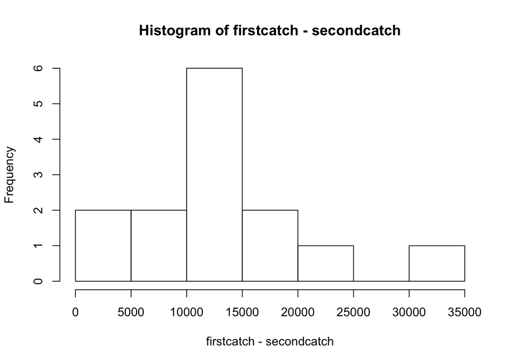

```r
firstcatch=c(91900,95200,61900,73600,114300,117000,129500,74200,112700,152100,90700,89400,127500,142200)
secondcatch=c(82900,86700,46900,41300,91600,100400,128400,55900,101700,139100,79300,76100,114100,139800)
hist(firstcatch-secondcatch)
```

#c)Explain what type of test should be used to test the hypothesis In order to test the hypothesis, a paired t-test should be used

#d)Run the appropriate test, and display the summary output

```r
t.test(firstcatch, secondcatch, paired=TRUE)
```

```
##
##  Paired t-test
##
## data:  firstcatch and secondcatch
## t = 6.3808, df = 13, p-value = 2.415e-05
## alternative hypothesis: true difference in means is not equal to 0
## 95 percent confidence interval:
##   8882.005 17975.138
## sample estimates:
## mean of the differences
##                13428.57
```

#e)Explicitely state the critical and observed value of the test statistic

```r
qt(0.975,13)
```

```
## [1] 2.160369
```

```r
qt(0.025,13)
```

```
## [1] -2.160369
```

```r
observed=6.3808
```

#f)Indicate what conclusion you would draw from the hypothesis test The p-value is small than 0.05, therefore we reject the null hypothesis. This means that there is a difference between shrimp catch from ships in 2009 and 2010

#Scenario 2 #a)State the null and alternative hypothesis null hypothesis: the phosphorus levels in the lake are within the guidelines alternative hypothesis: the phosporus levels in the lake are higther than the guidelines

#b)Create a histogram

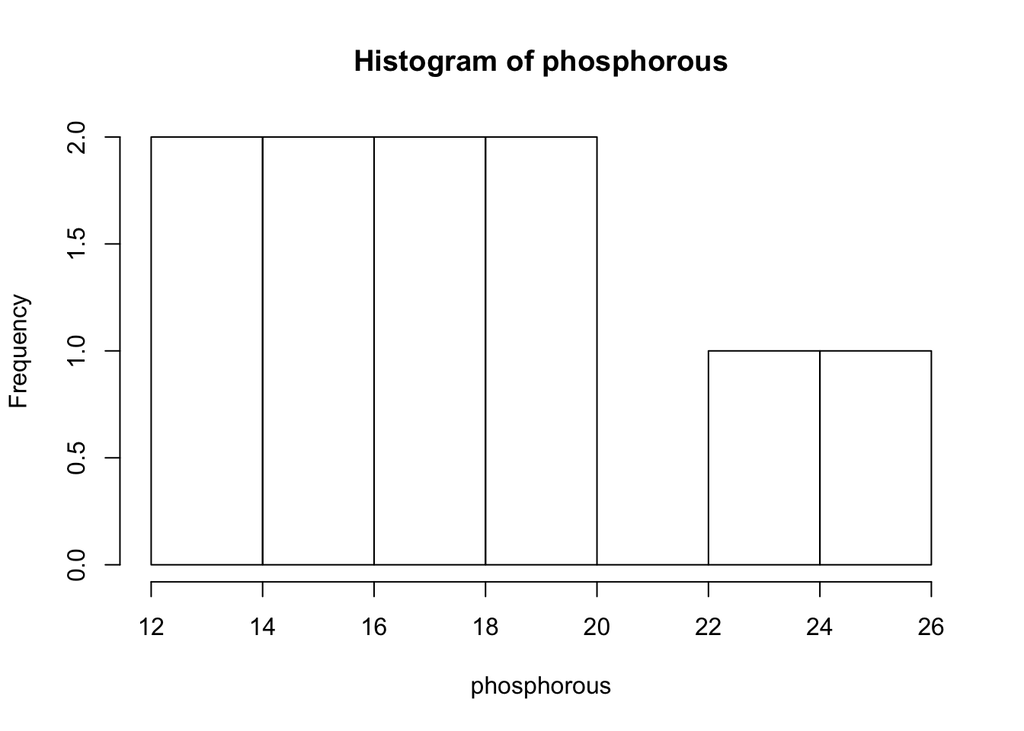

```r
phosphorous=c(18.4,12.9,15.3,18.3,15.6,23.3,16.5,12.3,24.6,16.2)
hist(phosphorous)
```

#c)Explain what type of test should be used to test the hypothesis In order to test the hypothesis, a one-sample t-test should be used

#d)Run the appropriate test, and display the summary output

```r
t.test(phosphorous, mu=15)
```

```
##
##  One Sample t-test
##
## data:  phosphorous
## t = 1.8462, df = 9, p-value = 0.09794
## alternative hypothesis: true mean is not equal to 15
## 95 percent confidence interval:
##  14.47278 20.20722
## sample estimates:
## mean of x
##     17.34
```

#e)Explicitely state the critical and observed value of the test statistic

```r
qt(0.95,9)
```

```
## [1] 1.833113
```

```r
observed=1.8462
```

#f)Indicate what conclusion you would draw from the hypothesis test

```r
p.value=0.09794/2
p.value
```

```
## [1] 0.04897
```

The p-value is small than 0.05, therefore we reject the null hypothesis. This means that the phosphorus levels in the lake are higher than the guidelines.

#Scenario 3 #a)State the null and alternative hypothesis null hypothesis: there is no difference in salmon growth rate when fed a vegetarian or carnivorous diet. alternative hypothesis: there is a difference in salmon growth rate when fed a vegetarian or carnivorous diet.

#b)Create a histogram

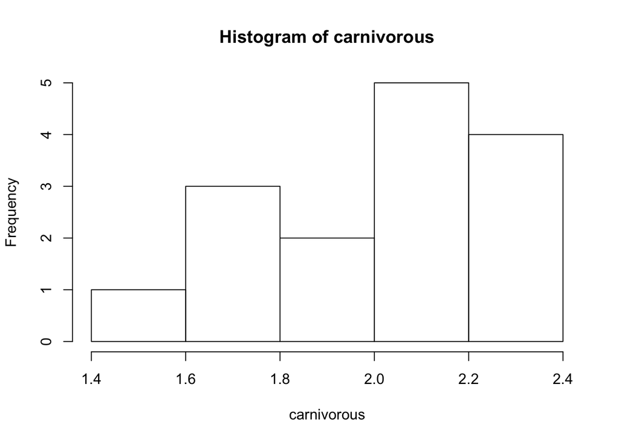

```r
carnivorous=c(2.3,1.8,1.9,1.8,2.1,2.3,2.0,2.2,2.2,1.5,1.8,2.1,2.3,2.2,2.3)
vegetarian=c(1.6,1.1,0.7,1.0,1.0,0.9,1.2,0.8,0.9,0.6,0.7,0.6,0.8,0.8,1.1)
hist(carnivorous)
```

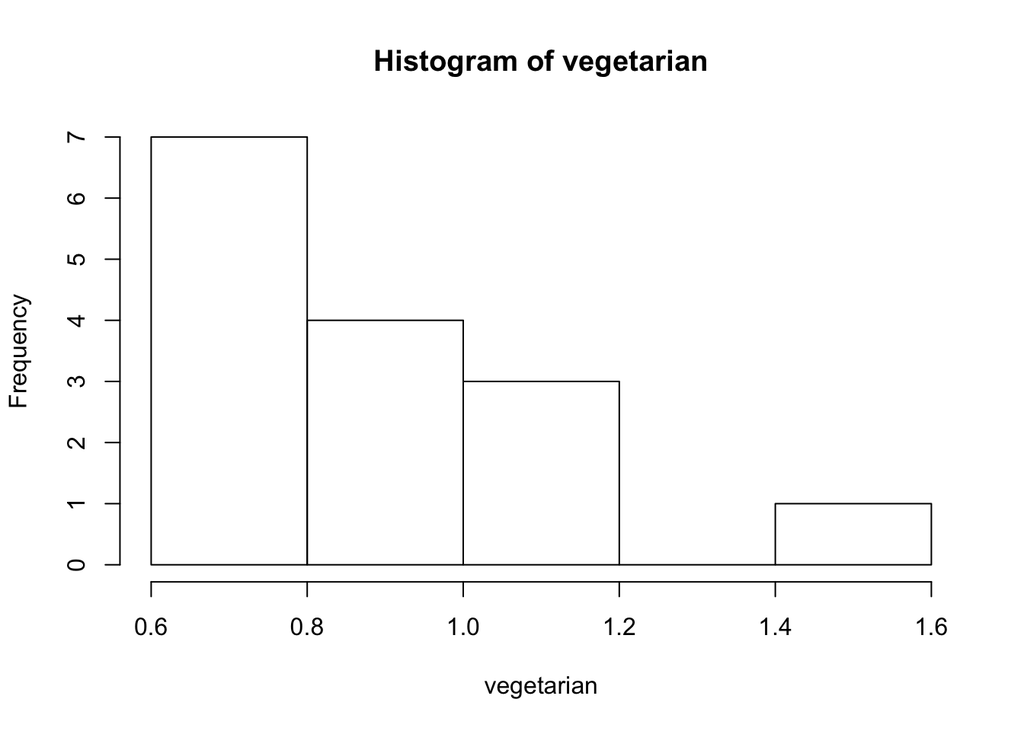

```r
hist(vegetarian)
```

#c)Explain what type of test should be used to test the hypothesis In order to test the hypothesis, an independent two-sample t-test should be used

#d)Run the appropriate test, and display the summary output

```r
t.test(carnivorous,vegetarian)
```

```
##
##  Welch Two Sample t-test
##
## data:  carnivorous and vegetarian
## t = 12.237, df = 27.862, p-value = 1.008e-12
## alternative hypothesis: true difference in means is not equal to 0
## 95 percent confidence interval:
##  0.9435752 1.3230915
## sample estimates:
## mean of x mean of y
##  2.053333  0.920000
```

#e)Explicitely state the critical and observed value of the test statistic

```r
qt(0.975,27.862)
```

```
## [1] 2.048864
```

```r
qt(0.025,27.862)
```

```
## [1] -2.048864
```

```r
observed=12.237
```

#f)Indicate what conclusion you would draw from the hypothesis test The p-value is small than 0.05, therefore we reject the null hypothesis. This means that there is a difference in salmon growth rate when fed a vegetarian or carnivorous diet.

#Scenario 4 #a)State the null and alternative hypothesis null hypothesis: there is no interaction between symptoms and the trophic level of the individual alternative hypothesis: there is an interaction between symptoms and the trophic level of the individual

```r
first.trophic=c(133,100,17)
top.predator=c(4,61,35)
my.data=data.frame(first.trophic, top.predator)
```

#c)Explain what type of test should be used to test the hypothesis In order to test the hypothesis, a Chi-squared test should be used

#d)Run the appropriate test, and display the summary output

```r
chisq.test(my.data)
```

```
##
##  Pearson's Chi-squared test
##
## data:  my.data
## X-squared = 89.253, df = 2, p-value < 2.2e-16
```

#e)Explicitely state the critical and observed value of the test statistic

```r
qt(0.95,2)
```

```
## [1] 2.919986
```

```r
observed=89.253
```

#f)Indicate what conclusion you would draw from the hypothesis test The p-value is small than 0.05, therefore we reject the null hypothesis. This means that there is an interaction between symptoms and trophic levels.